# BIOINF3005/7160: Transcriptomics Applications

Week 7.2: More Complex Designs (Part 2)

1<sup>st</sup> May 2020

# Introduction

## Recap

In our previous session, we started to explore a 4-way layout and looked at some options for analysing this dataset. Today we’ll continue looking through this dataset and we’ll allow considerable time for exploring the data on our own and making our own decisions on how to characterise biological patterns.

If you’d like to start a new markdown, that may be wise. You can stay in the same R Project as our previous session. We’ll use the same dataset so won’t need any extra files besides the ones we download.

## Setup

Set-up your YAML header as you like. Here’s my example

```
---
title: "BIOINF3005/7160:<br>Transcriptomics Applications"
subtitle: "Week 7.2: More Complex Designs (Part 2)"
author: Some Genius
date: "1^st^ May 2020"
output:
  html_document:
    toc: yes
    toc_float: yes
---
```

And your setup chunk

````
```{r setup}
knitr::opts_chunk$set(
    echo = TRUE,
    message = FALSE,
    warning = FALSE,
    fig.align = "center"
)
```
````

Here are the packages we’ll need, so add these to your packages chunk. I’ve also included my `theme_set(theme_bw())` command here, which sets my preferred theme for `ggplot2`.

```r
library(Biobase)
library(limma)
library(magrittr)
library(tidyverse)
library(UpSetR)
library(pheatmap)
library(scales)
library(ggfortify)
library(pander)
library(cowplot)
theme_set(theme_bw())
```

Finally, the data we’ll need is created as an `ExpressionSet` a similar way, but let’s simplify it this time. First we’ll define the base path, then add the individual files in the object `urls`.

```r
urls <- paste0(
    "https://github.com/UofABioinformaticsHub/transcriptomics_applications/raw/master/practicals/data/",
    c("pi16_Th_eset.rds", "pi16_Treg_eset.rds")
)
```

For each web address (i.e. URL), we need to pass this to the R function `url()` so R knows to treat this as a remote connection. From there we can just read the files in as if they’re local files on your hard drive. We won’t need them as individual files today, so let’s just place the straight into the object.

```r
eset <- Biobase::combine(
    urls[[1]] %>% url %>% read_rds(),
    urls[[2]] %>% url %>% read_rds()
)
```

**Handy hint: A good trick can be to name each chunk with the name of an object you create in the chunk**

```r
pData(eset)$cell_type <- as.factor(pData(eset)$cell_type)
pData(eset) <- pData(eset) %>%
  mutate(
    group = case_when(
      PI16 == "+" ~ paste0(cell_type, "_PI16_plus"),
      PI16 == "-" ~ paste0(cell_type, "_PI16_minus")
    ),
    group = as.factor(group)
  )
colnames(eset) <- pData(eset)$array_id
```

*Note: that last line was required as the `mutate()` removed rownames from `pData`, which removed column names from `eset`.* *`dplyr` is brilliant, but every now & then it’s quite frustrating.*

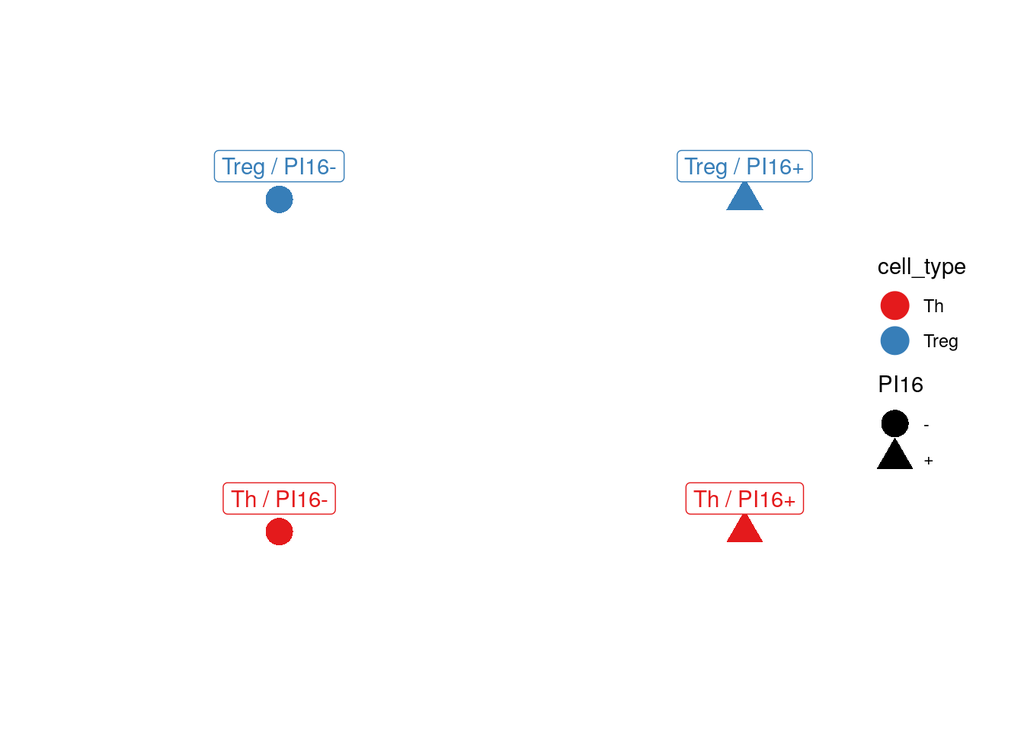

# Analysis

## Check our Data

The first step of any analysis is to check the data. For microarrays (and RNA-Seq) the first step should be checking out distributions relative to each other. This will help us spot if any samples have any unexpected issues.

```r
plotDensities(eset)
```

```r
pca <- exprs(eset) %>%
  t() %>%
  prcomp()
pca %>%
  autoplot(
    data = pData(eset),
    colour = "group",
    size = 4
  ) +
  stat_ellipse(
    aes(colour = group),
    fill = NA,
    geom = "polygon",
    show.legend = FALSE
  ) +
  scale_colour_brewer(palette = "Paired")
```

## Using an Interaction Term

Remember that an estimate of the expression level in each cell grouping is additive based on the model coefficients. For a significant ‘interaction’ term, this means we have a response which is not as expected by adding the two coefficients on their own. This type of model has it’s origins in engineering applications when you might test the strength of a material in temperature and pressure. Any unexpected result which is not additive indicates the two predictor variables have some kind of interaction, hence the name.

Last time we discussed interaction terms by looking at a few examples. Have a look at the following expression patterns, and see which ones you think would give a significant interaction term.

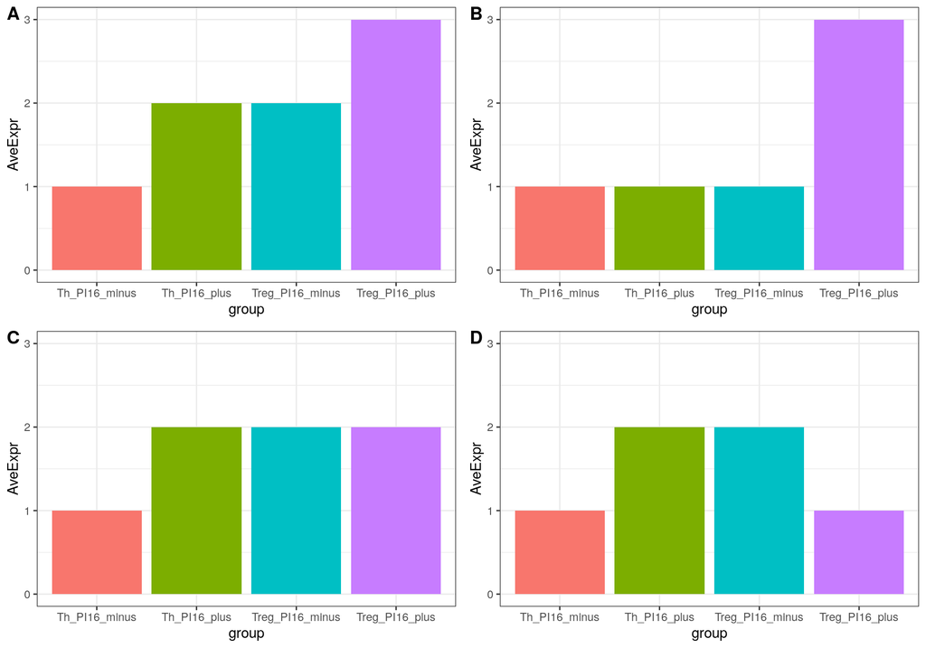

Let’s define our model matrix with an interaction term and fit the model using `lmFit()`

```r
X_int <- model.matrix(~ (cell_type + PI16)^2, data = pData(eset))
X_int
```

```r
fit_int <- lmFit(eset, X_int) %>%
    eBayes()
```

Check the topTables (very crudely). Notice we’re ignoring the Intercept term, as that just represents the baseline expression level in PI16<sup>-</sup> Th cells. Clearly, this is not a comparison.

Instead of doing the other coefficients one at a time, let’s just take the column names of our model matrix and pass them to topTable using a dummy variable `nm`.

```r
for (nm in colnames(X_int)[2:4]) {
    print(topTable(fit_int, coef = nm))
}
```

We can use this trick with `lapply()` to collate our results. Here, we’re writing a function *on-the-fly* which takes a single argument `x`. The column names from `X_int` will be passed to this function one at a time and inside the function, they will be referred to as `x`. You can see them in the call to `topTable()`. Notice that we’re also including them as a column called `coef`, after we’ve removed uninteresting columns using `dplyr::select()`.

```r
results_int <- colnames(X_int)[2:4] %>%
  lapply(function(x){
    topTable(fit_int, coef = x, number = Inf) %>%
      dplyr::select(starts_with("gene"), logFC, AveExpr, contains("P.Val")) %>%
      mutate(coef = x) %>%
      as_tibble()
  }) %>%
  set_names(
    colnames(X_int)[2:4]
  )
```

Let’s check our results to see how many DE genes we had.

```r
results_int %>%
    lapply(dplyr::filter, adj.P.Val < 0.05) %>%
    lapply(nrow)
```

We could use a 3-way Venn Diagram to find this out, but a more recently proposed plotting style is known as an UpSet plot. These allow for Venn Diagram-like information to be communicated where there are enough groups to make a Venn Diagram look messy.

The simplest way to generate these plots is to provide a list of groups with the common labels (i.e. gene ids), and the function `fromList()` will structure the data ready for the plotting function.

```r
results_int %>%
    lapply(dplyr::filter, adj.P.Val < 0.05) %>%
    lapply(extract2, "gene_id") %>%
    fromList() %>%
    upset()
```

Once you get the hang of these they’re very easy to interpret.

### Genes Significant Everywhere

```r
results_int %>%
  bind_rows() %>%
  dplyr::filter(adj.P.Val < 0.05) %>%
  group_by(gene_id, gene_name) %>%
  tally() %>%
  dplyr::filter(n == 3)
```

Now we know how to find this gene, let’s make a boxplot to check it’s expression.

```r
results_int %>%
  bind_rows() %>%
  dplyr::filter(adj.P.Val < 0.05) %>%
  group_by(gene_id, gene_name) %>%
  tally() %>%
  dplyr::filter(n == 3) %>%
  ungroup() %>%
  cbind(
    exprs(eset)[paste0(.$gene_id, "_at"),] %>%
      matrix(ncol = ncol(eset)) %>%
      set_colnames(colnames(eset))
  ) %>%
  pivot_longer(
    starts_with("SB"),
    names_to = "array_id",
    values_to = "exprs"
  ) %>%
  left_join(
    pData(eset)
  ) %>%
  ggplot(aes(group, exprs, fill = group)) +
  geom_boxplot() +
  scale_fill_brewer(palette = "Paired")
```

### Treg Genes with an Interaction Term

Another group of genes which might be worth exploring might be genes with a Treg effect, but with a significant interaction term.

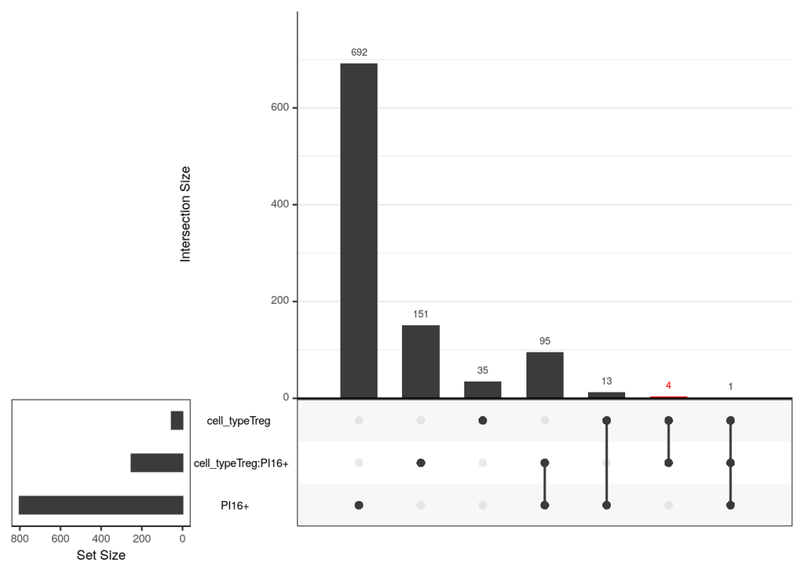

First we’ll just get the gene IDs to make sure we’ve grabbed what we expect. Notice that we’re using `filter()` whilst grouped, which will remove all genes from a grouping that match the exclusion criteria.

```r
results_int %>%
    bind_rows() %>%
    dplyr::filter(adj.P.Val < 0.05) %>%
    group_by(gene_id) %>%
    mutate(n = n()) %>%
    dplyr::filter(n == 2 & !"PI16+" %in% coef) %>%
    ungroup() %>%
    distinct(gene_id, gene_name)
```

As there’s only 4, a box plot might be a good move again.

```r
results_int %>%
  bind_rows() %>%
  dplyr::filter(adj.P.Val < 0.05) %>%
  group_by(gene_id) %>%
  mutate(n = n()) %>%
  dplyr::filter(n == 2 & !"PI16+" %in% coef) %>%
  ungroup() %>%
  distinct(gene_id, gene_name) %>%
  cbind(
    exprs(eset)[paste0(.$gene_id, "_at"),]
  ) %>%
  pivot_longer(
    starts_with("SB"),
    names_to = "array_id",
    values_to = "exprs"
  ) %>%
  left_join(
    pData(eset)
  ) %>%
  ggplot(aes(group, exprs, fill = group)) +
  geom_boxplot() +
  facet_wrap(~gene_name) +
  scale_fill_brewer(palette = "Paired")
```

### Treg Genes with no Interaction Term

Genes with a Treg effect, but with no PI16 effects or interaction might be another group to explore. As this is a larger group, perhaps a heatmap might be best for exploration.

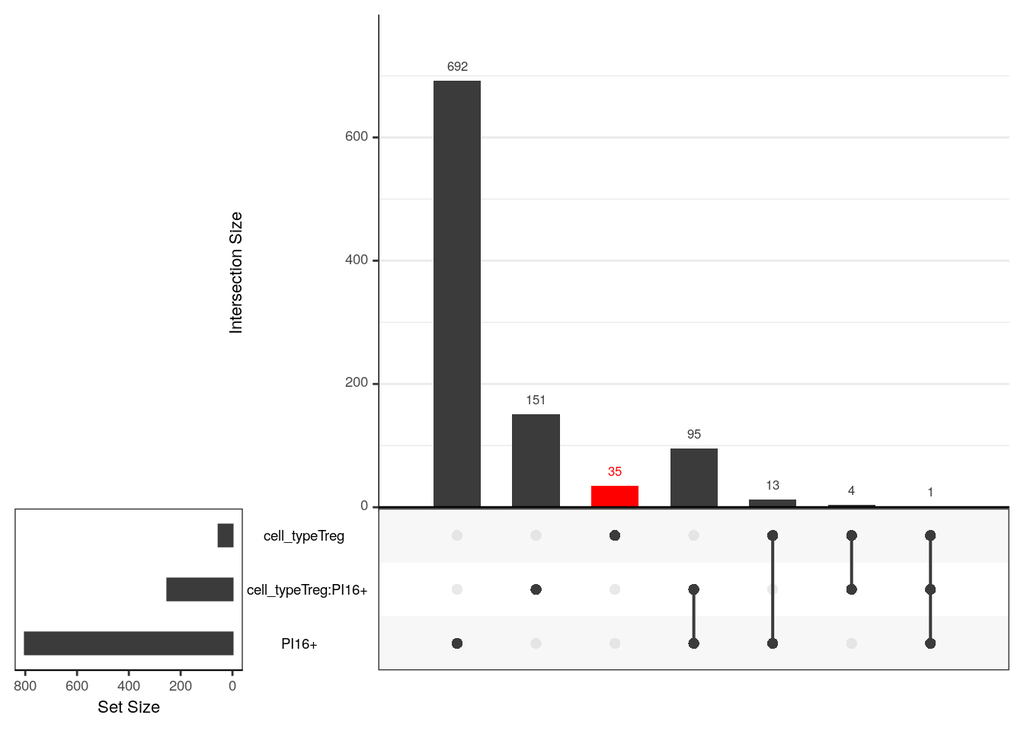

First we’ll check that we know how to grab the gene IDs.

```r
results_int %>%
    bind_rows() %>%
    dplyr::filter(adj.P.Val < 0.05) %>%
    group_by(gene_id) %>%
    mutate(n = n()) %>%
    ungroup() %>%
    dplyr::filter(
        n == 1 & coef == "cell_typeTreg"
    )
```

Now we know that we can get the heatmap going.

```r
results_int %>%
    bind_rows() %>%
    dplyr::filter(adj.P.Val < 0.05) %>%
    group_by(gene_id) %>%
    mutate(n = n()) %>%
    ungroup() %>%
    dplyr::filter(
        n == 1 & coef == "cell_typeTreg"
    ) %>%
    cbind(
        exprs(eset)[paste0(.$gene_id, "_at"),]
    ) %>%
    set_rownames(.$gene_name) %>%
    dplyr::select(starts_with("SB")) %>%
    pheatmap(
        color = viridis_pal(option = "magma")(100),
        cutree_cols = 2,
        cutree_rows = 2
    )
```

[output not shown]

Does this look how you might have expected?

### Pick one more group

**If we’re doing well with time, choose one of these groups your self and try to extract the genes from that group as a heatmap.**

## Concerns With This Method

Overall, this method is statistically robust and a good strategy in these types of designs. How we interpret the interaction term can be difficult to define, and it actually captures multiple gene expression patterns. This can make it difficult to describe differential expression patterns.

In the above approach we didn’t use a contrast matrix. Could we have done so?

An alternative approach may be to simply define expression estimates and perform a series of pair-wise comparisons.

# Using Pair-wise Comparisons

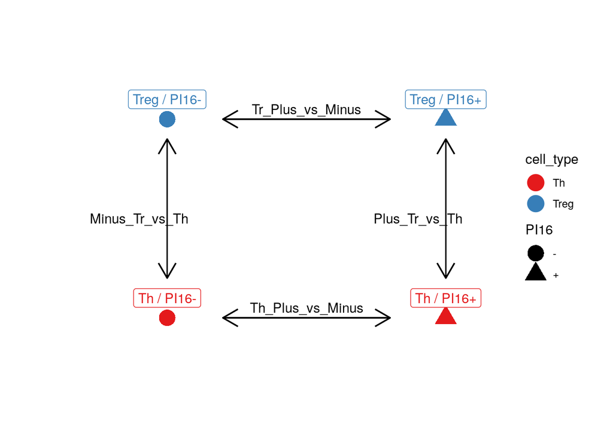

Our gene expression estimates will not change using this method, or if we manually performed all of the sums required under a model with an interaction term. A key point about this model is that pair-wise comparisons become much simpler to extract from our design matrix in order to form our contrasts. Let’s setup a simple design matrix with the contrasts as described above.

```r
X_pairs <- model.matrix(~ 0 + group, data = pData(eset)) %>%
  set_colnames(
    str_remove(colnames(.), "group")
  )
cont_pairs <- makeContrasts(
  Tr_Plus_vs_Minus = Treg_PI16_plus - Treg_PI16_minus,
  Th_Plus_vs_Minus = Th_PI16_plus - Th_PI16_minus,
  Plus_Tr_vs_Th = Treg_PI16_plus - Th_PI16_plus,
  Minus_Tr_vs_Th = Treg_PI16_minus - Th_PI16_minus,
  levels = colnames(X_pairs)
)
```

Now we can fit the dataset as expected.

```r
fit_pairs <- lmFit(eset, design = X_pairs) %>%
  contrasts.fit(cont_pairs) %>%
  eBayes()
```

Let’s form another list of results as beforehand, except this time we’ll have four pair-wise comparisons.

```r
results_pairs <- colnames(cont_pairs) %>%
  lapply(function(x){
    topTable(fit_pairs, coef = x, number = Inf) %>%
      as_tibble() %>%
      dplyr::select(starts_with("gene"), logFC, AveExpr, contains("P.Val")) %>%
      mutate(comparison = x)
  }
  ) %>%
  set_names(
    colnames(cont_pairs)
  )
```

Check how many De genes we have again.

```r
results_pairs %>%
    lapply(dplyr::filter, adj.P.Val < 0.05) %>%
    lapply(nrow)
```

```r
results_pairs %>%
    lapply(dplyr::filter, adj.P.Val < 0.05) %>%
    lapply(extract2, "gene_name") %>%
    fromList() %>%
    upset()
```

[output not shown]

**Can anyone see a significant issue with these results?**

(Hint: Can a gene be truly DE in only one comparison?)

Let’s check our volcano plots, colouring points with an FDR-adjusted p-value < 0.05, and adding our tram-lines at logFC = $\pm1$.

```r
results_pairs %>%
  bind_rows() %>%
  mutate(DE = adj.P.Val < 0.05) %>%
  ggplot(aes(logFC, -log10(P.Value), colour = DE)) +
  geom_point() +
  geom_vline(
    xintercept = c(-1, 1),
    linetype = 2,
    colour = "grey"
  ) +
  geom_text(
    aes(x, y, label = label),
    data = . %>%
      group_by(comparison) %>%
      summarise(n = sum(DE)) %>%
      mutate(
        x = -3, y = 0,
        label = paste0("n = ", n)
      ),
    inherit.aes = FALSE
  ) +
  facet_wrap(~comparison) +
  scale_colour_manual(values = c("black", "red"))
```

[output not shown]

## Strategies for Gene Selection

In order to obtain the most significant genes (i.e. the low hanging fruit), we can perform an analysis in two steps.

1. We select a list of DE genes using a logFC filter and a FDR-adjust p-value < 0.05
2. In order to correctly characterise the behaviour of these genes, we remove the logFC filter from other comparisons
   - We may even change the FDR filter

This is connected to the idea of hard-cutoffs we mentioned the other day.

```r
allDE <- results_pairs %>%
  bind_rows() %>%
  dplyr::filter(adj.P.Val < 0.05 & abs(logFC) > 1) %>%
  extract2("gene_id") %>%
  unique()
length(allDE)
```

```r
results_pairs %>%
    lapply(
      dplyr::filter, adj.P.Val < 0.1 & gene_id %in% allDE
    ) %>%
    lapply(extract2, "gene_name") %>%
    fromList() %>%
    upset()
```

## Tasks

1. Genes consistently tracking with PI16, but with no Treg effect
2. Genes consistently tracking with Tregs, but with no PI16 effect
3. Genes which are different across every pair-wise comparison

Once you’ve done those, try a couple more.

## Advanced challenge

Can you think of a way to include direction in these lists, instead of just significance? **NB: This is a very hard challenge.** Don’t be surprised if you don’t get it, but I will be thrilled if someone does.

# Conclusion

This type of analysis is very common, where you seek to carefully characterise the behaviour of genes across multiple conditions. From here we would move to finding biological pathways that seem to be enriched in these groups.

With these analyses, there is no right or wrong answer, just (within reason) alternative strategies. Sometimes models using interaction terms are the ‘best solution’ to the problem, other times pair-wise comparisons may be a simple option.